# Wind Power Project

By Elliot Cohen, Mike Waite, Joe Woo and Vijay Modi

October 20, 2014

# Part 1: An exploration of wind energy data

Suppose you are hired as a consultant to evaluate the potential for wind energy production on a small chain of islands in the Atlantic Ocean. The islands already have one wind farm up and running, with 7 Vestas wind turbines (v52-850Kw) rated at 850kW each. The combined rated capacity of the 7 turbines is 5950 kW, which is roughly 75.1% of the annual average power demand for the island! This is a huge penetration of wind! Pairwise observations of [10-minute average wind speed and cummulative wind energy production](https://github.com/Ecohen4/ECREEE/blob/master/WIND_VXE_2013_ORIGINAL.xls) data are provided by the utility for the most recent year, in .xls format (click “view raw” to download). [Hourly demand](https://github.com/Ecohen4/ECREEE/blob/master/VXE_Estimated_Hourly_Load.csv) was estimated in-house from the load profile of a nearby island, and is provided in .csv format.

Using this data, prepare the following material for an investor meeting coming up next week. Be sure to document any assumptions, equations or algorithims implimented, and include all underlying R code in a well-commented [Rmarkdown](http://rmarkdown.rstudio.com/) file. [Knit](http://yihui.name/knitr/) the .rmd into a clean .html or .pdf file for review.

1. Visually inspect the data!
   - Does it make sense?
   - Are there any obvious issues, such as missing data, incomplete records or suspect values?
2. Compute summary statistics to make sure the values make sense (use benchmark comparisons!).
3. Clean the data. There are two schools of thought on this:
   - Option 1: Remove all records containing suspect/questionable data. For example:
     - Can you have negative energy values?
     - Can you produce 400kw at 0 windspeed?
     - If the wind and/or power data at a given timestamp are not reasonable on their own *or* do not make sense together as a pairwise observation, omit them.
     - Use textbook knowledge of wind energy systems as one check (hint: Betz Limit!)
     - Keep track of how many observations you remove!
   - Option 2: Data correction, using textbook knowledge (hint: turbine power curve!).
   - After implementing step 3 (option 1 or 2), you should have a “clean” dataset. Now make engineering computations with confidence! Proceed to steps 4-9 (and 10-11 if you’re extra ambitious!)
4. Total wind energy produced last year (e.g. KWh delivered to the grid).
5. Capacity factor of the current system.
6. Total wind energy that was *possible* given the observed windspeeds and the [turbine power curve](https://github.com/Ecohen4/ECREEE/blob/master/v52-850KW-power-curve.csv). This is the uncurtailed power output.
7. Uncurtailed capacity factor using the result from 6 (this assumes the grid can accept the full uncurtailed power output).
8. Turbine efficiency (hint: you will have to compute the kinetic energy contained in the wind!):
   - average efficiency for the entire windfarm; and
   - efficiency as a function of windspeed.
   - compare with Betz Limit.
9. Characterization of the wind resource using a Weibull distribution.
10. **BONUS** Randomly generate a year’s worth of new windspeed data according to the fitted Weibull distrubution. Using the new windspeeds, predict what the resulting wind energy production may look like next year.
11. **BONUS** Repeat step 10 500 times and compute the capacity factor each time. Boxplot the results of the 500 simulations. This is called an ensemble forecast.

## Data Cleaning

### Import data from .csv

```r
setwd("~/github/ECREEE")
data.raw <- read.csv(file = "WIND_VXE_2013_original.csv", header = TRUE)
```

### Assign succint, descriptive column names

```r
# assign new column names to be more succint (avoid spaces, use _ or . to
# seperate words)
new.names <- c("date_time", "T1_Possible_Power", "T2_Possible_Power", "T3_Possible_Power",
    "T4_Possible_Power", "T5_Possible_Power", "T6_Possible_Power", "T7_Possible_Power",
    "T1_Total_Active_Power", "T2_Total_Active_Power", "T3_Total_Active_Power",
    "T4_Total_Active_Power", "T5_Total_Active_Power", "T6_Total_Active_Power",
    "T7_Total_Active_Power", "mean_wind_mps", "min_wind_mps", "max_wind_mps",
    "cum_energy_delivered_kwh")

# make sure the new names lineup properly with the ones they're replacing...
cbind(names(data.raw), new.names)

# if yes, replace column names with new names
names(data.raw) <- new.names

# Let's create a data frame that we'll work on as we go, so that we can
# always come back and reference the raw data if we'd like to
data <- data.raw
```

### Format timestamp

```r
# Use 'UTC' to avoid daylight savings
data$date_time <- as.POSIXct(data$date_time, format = "%m/%d/%y %H:%M", tz = "UTC")
```

### Energy Delivered

We know our energy data is coming in as a cumulative meter. We can check this with a time series plot.

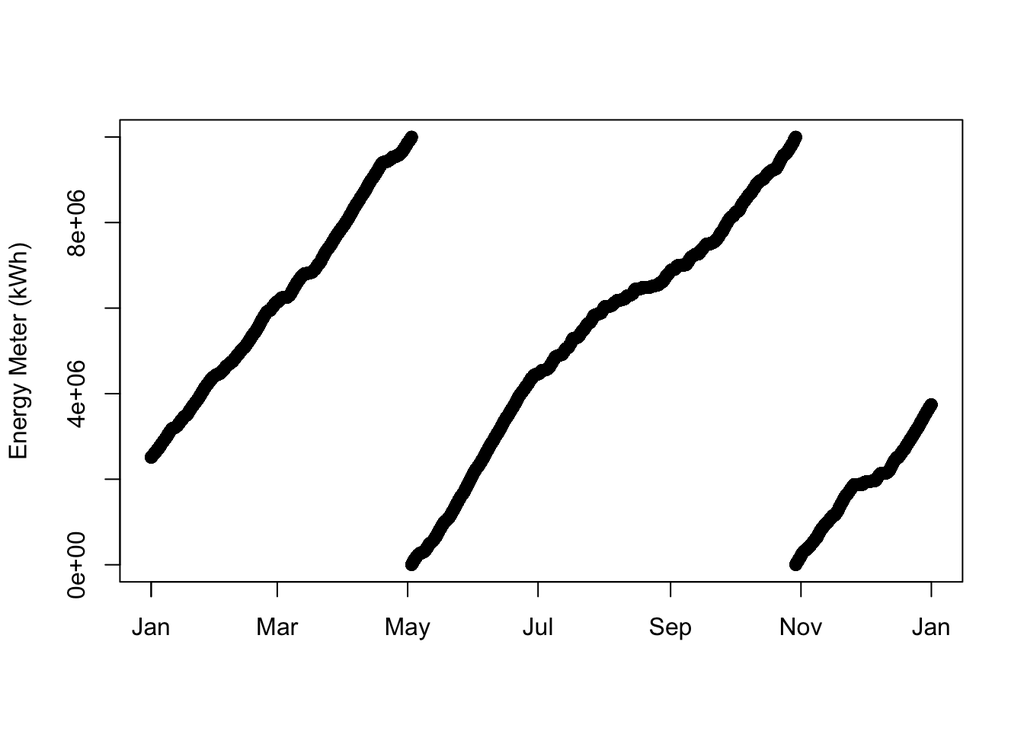

```r
# Calculate energy delivered at each time step
data$energy_delivered_kwh <- c(data$cum_energy_delivered_kwh[2:nrow(data)] -
    data$cum_energy_delivered_kwh[1:(nrow(data) - 1)], 0)
# We know negative values with this approach will be the actual value minus
# 10^7
data$energy_delivered_kwh <- ifelse(data$energy_delivered_kwh < 0, data$energy_delivered_kwh +
    10^7, data$energy_delivered_kwh)
```

### Check for missing values

We can check for NAs and other things we don’t particularly like as we go, but to make it quicker later, let’s write a custom function that easily conveys information regarding missing values. It wraps several useful checks into a single function:

```r
check <- function(df) {
    # count NA (missing values)
    NAs <- sum(is.na(df))
    print(paste("Missing Values:", NAs))

    # count incomplete records (rows containing missing values)
    ok <- complete.cases(df)
    print(paste("Incomplete Records:", sum(!ok)))

    # Show incomplete records (if less than 100 NAs).
    if (NAs > 0 & NAs <= 100)
        print(df[which(!complete.cases(df)), ])

    # If more than 100, show column-wise distribution of NAs.
    if (NAs > 100)
        hist(which(is.na(df), arr.ind = TRUE)[, 2], xlab = "Column", freq = TRUE,
            breaks = 1:dim(df)[2], main = "Column-wise distribution of missing values")
}
```

Similarly, we can write another quick function to show how many records are removed in any subset operation:

```r
removed <- function(nrow, nrow1) {
    print(paste("number of records REMOVED:", nrow - nrow1, sep = " "))
    print(paste("number of records REMAINING:", nrow1, sep = " "))
}
```

Now let’s take our `check` function for a test drive!

```r
check(data)  # NAs present. Column-wise distribution is relatively uniform (besides wind with relatively few)
```

```
## [1] "Missing Values: 10622"
## [1] "Incomplete Records: 1736"
```

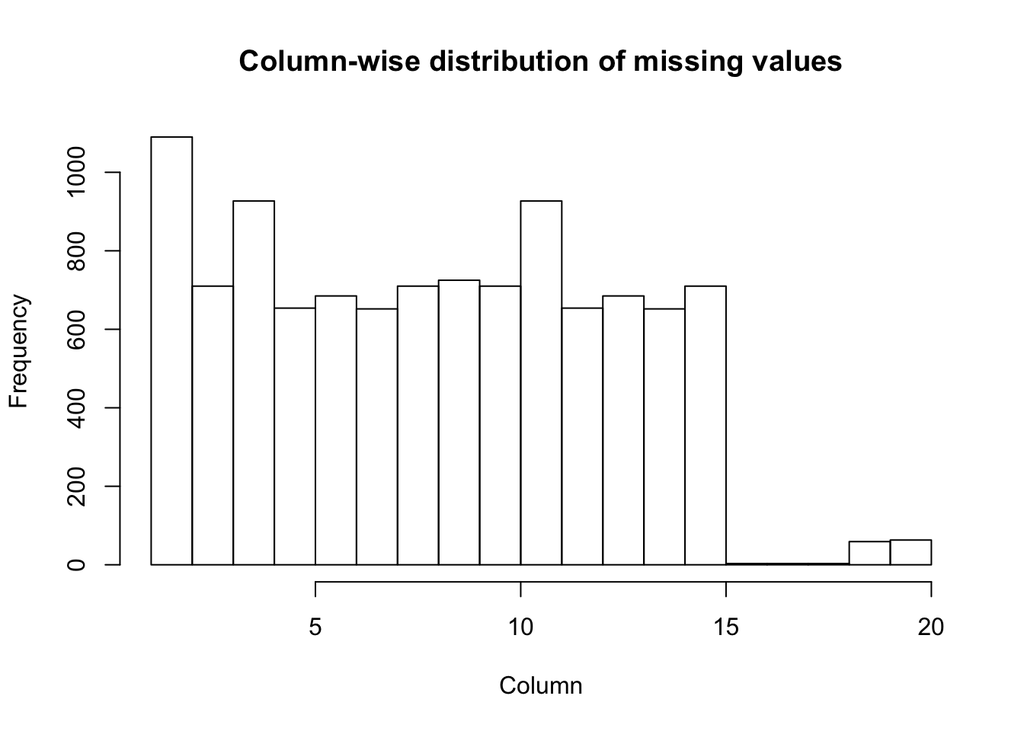

```r
summary(data)
```

```
##    date_time                   T1_Possible_Power T2_Possible_Power
##  Min.   :2013-01-01 00:10:00   Min.   : -3.0     Min.   : -3.0
##  1st Qu.:2013-04-02 06:05:00   1st Qu.:191.0     1st Qu.:204.0
##  Median :2013-07-02 12:00:00   Median :518.0     Median :530.0
##  Mean   :2013-07-02 12:00:00   Mean   :475.9     Mean   :483.5
##  3rd Qu.:2013-10-01 17:55:00   3rd Qu.:772.0     3rd Qu.:774.0
##  Max.   :2013-12-31 23:50:00   Max.   :850.0     Max.   :850.0
##  NA's   :365                   NA's   :725       NA's   :710
##  T3_Possible_Power T4_Possible_Power T5_Possible_Power T6_Possible_Power
##  Min.   : -2.0     Min.   : -3.0     Min.   : -3.0     Min.   : -2.0
##  1st Qu.:214.0     1st Qu.:222.0     1st Qu.:192.0     1st Qu.:206.0
##  Median :552.0     Median :598.0     Median :553.0     Median :537.0
##  Mean   :496.8     Mean   :517.6     Mean   :495.3     Mean   :489.3
##  3rd Qu.:792.0     3rd Qu.:819.0     3rd Qu.:805.0     3rd Qu.:786.0
##  Max.   :850.0     Max.   :850.0     Max.   :850.0     Max.   :850.0
##  NA's   :927       NA's   :654       NA's   :685       NA's   :652
##  T7_Possible_Power T1_Total_Active_Power T2_Total_Active_Power
##  Min.   : -6       Min.   :3109970       Min.   : 609852
##  1st Qu.:180       1st Qu.:3895622       1st Qu.:1391641
##  Median :497       Median :4744043       Median :2341906
##  Mean   :472       Mean   :4608851       Mean   :2189450
##  3rd Qu.:785       3rd Qu.:5262894       3rd Qu.:2894952
##  Max.   :850       Max.   :6045048       Max.   :3690817
##  NA's   :710       NA's   :725           NA's   :710
##  T3_Total_Active_Power T4_Total_Active_Power T5_Total_Active_Power
##  Min.   :3254759       Min.   :3341303       Min.   :3230186
##  1st Qu.:4066341       1st Qu.:4168935       1st Qu.:4023712
##  Median :5022455       Median :5159420       Median :4986563
##  Mean   :4870726       Mean   :5003720       Mean   :4827587
##  3rd Qu.:5586471       3rd Qu.:5736883       3rd Qu.:5531891
##  Max.   :6413840       Max.   :6575858       Max.   :6326853
##  NA's   :927           NA's   :654           NA's   :685
##  T6_Total_Active_Power T7_Total_Active_Power mean_wind_mps
##  Min.   :3264175       Min.   :3136754       Min.   : 0.00
##  1st Qu.:4085929       1st Qu.:3919523       1st Qu.: 5.60
##  Median :5057922       Median :4875312       Median : 8.50
##  Mean   :4903693       Mean   :4712335       Mean   : 8.08
##  3rd Qu.:5624685       3rd Qu.:5410488       3rd Qu.:10.90
##  Max.   :6451012       Max.   :6193951       Max.   :18.80
##  NA's   :652           NA's   :710           NA's   :3
##   min_wind_mps   max_wind_mps   cum_energy_delivered_kwh
##  Min.   : 0.0   Min.   : 0.00   Min.   :     78
##  1st Qu.: 3.6   1st Qu.: 7.60   1st Qu.:2741038
##  Median : 6.0   Median :11.10   Median :5152314
##  Mean   : 5.6   Mean   :10.55   Mean   :5052061
##  3rd Qu.: 7.8   3rd Qu.:13.90   3rd Qu.:7152592
##  Max.   :15.8   Max.   :31.50   Max.   :9999699
##  NA's   :3      NA's   :3       NA's   :59
##  energy_delivered_kwh
##  Min.   :  0.0
##  1st Qu.:217.0
##  Median :417.0
##  Mean   :404.4
##  3rd Qu.:584.0
##  Max.   :964.0
##  NA's   :63
```

### Remove missing values

Apply the `na.omit` function {stats package} to create a new dataframe called `dat` with all NAs removed.  
Apply the `removed` function {user defined} to compare the two data frames.

```r
nrow.orig <- nrow(data)[1]  # record the dimensions of the data (before removing anything!)
data <- na.omit(data)  # omit rows containing missing values
nrow.new <- dim(data)[1]  # record the new dimensions of the data (after removing NAs)
removed(nrow.orig, nrow.new)  # check how many records have been removed
```

```
## [1] "number of records REMOVED: 1736"
## [1] "number of records REMAINING: 50824"
```

```r
summary(data)
```

```
##    date_time                   T1_Possible_Power T2_Possible_Power
##  Min.   :2013-01-01 00:10:00   Min.   : -3.0     Min.   : -3.0
##  1st Qu.:2013-04-01 01:07:30   1st Qu.:196.0     1st Qu.:209.0
##  Median :2013-06-29 09:45:00   Median :522.0     Median :533.5
##  Mean   :2013-06-30 23:06:26   Mean   :478.6     Mean   :486.1
##  3rd Qu.:2013-09-30 18:42:30   3rd Qu.:773.0     3rd Qu.:774.0
##  Max.   :2013-12-31 23:50:00   Max.   :850.0     Max.   :850.0
##  T3_Possible_Power T4_Possible_Power T5_Possible_Power T6_Possible_Power
##  Min.   : -2.0     Min.   : -3.0     Min.   : -3.0     Min.   : -2.0
##  1st Qu.:215.0     1st Qu.:229.0     1st Qu.:197.0     1st Qu.:213.0
##  Median :552.0     Median :602.0     Median :557.0     Median :541.0
##  Mean   :497.3     Mean   :520.9     Mean   :498.3     Mean   :492.3
##  3rd Qu.:792.0     3rd Qu.:820.0     3rd Qu.:805.0     3rd Qu.:787.0
##  Max.   :850.0     Max.   :850.0     Max.   :850.0     Max.   :850.0
##  T7_Possible_Power T1_Total_Active_Power T2_Total_Active_Power
##  Min.   : -6.0     Min.   :3110050       Min.   : 609933
##  1st Qu.:185.0     1st Qu.:3887168       1st Qu.:1381959
##  Median :502.0     Median :4740792       Median :2338364
##  Mean   :475.2     Mean   :4603100       Mean   :2182388
##  3rd Qu.:786.0     3rd Qu.:5259157       3rd Qu.:2888498
##  Max.   :850.0     Max.   :6045048       Max.   :3690817
##  T3_Total_Active_Power T4_Total_Active_Power T5_Total_Active_Power
##  Min.   :3254839       Min.   :3341384       Min.   :3230266
##  1st Qu.:4063115       1st Qu.:4159108       1st Qu.:4015241
##  Median :5019781       Median :5155553       Median :4983179
##  Mean   :4865390       Mean   :4996250       Mean   :4821182
##  3rd Qu.:5577010       3rd Qu.:5730811       3rd Qu.:5527292
##  Max.   :6413840       Max.   :6575858       Max.   :6326853
##  T6_Total_Active_Power T7_Total_Active_Power mean_wind_mps
##  Min.   :3264255       Min.   :3136835       Min.   : 0.000
##  1st Qu.:4074466       1st Qu.:3910851       1st Qu.: 5.700
##  Median :5053618       Median :4872252       Median : 8.600
##  Mean   :4895615       Mean   :4705391       Mean   : 8.118
##  3rd Qu.:5618021       3rd Qu.:5406416       3rd Qu.:10.900
##  Max.   :6451012       Max.   :6193951       Max.   :18.800
##   min_wind_mps     max_wind_mps  cum_energy_delivered_kwh
##  Min.   : 0.000   Min.   : 0.0   Min.   :     78
##  1st Qu.: 3.700   1st Qu.: 7.7   1st Qu.:2752997
##  Median : 6.000   Median :11.1   Median :5139952
##  Mean   : 5.626   Mean   :10.6   Mean   :5048761
##  3rd Qu.: 7.800   3rd Qu.:13.9   3rd Qu.:7198442
##  Max.   :15.800   Max.   :31.5   Max.   :9999699
##  energy_delivered_kwh
##  Min.   :  0.0
##  1st Qu.:235.0
##  Median :417.0
##  Mean   :411.5
##  3rd Qu.:585.0
##  Max.   :964.0
```

### Pairwise observations: Power vs Windspeed

Now let’s check if the windspeed and energy measurements make sense together (e.g. pairwise observations).  
Recall this is timeseries data, so at every timestamp there is a windspeed and energy measurement.

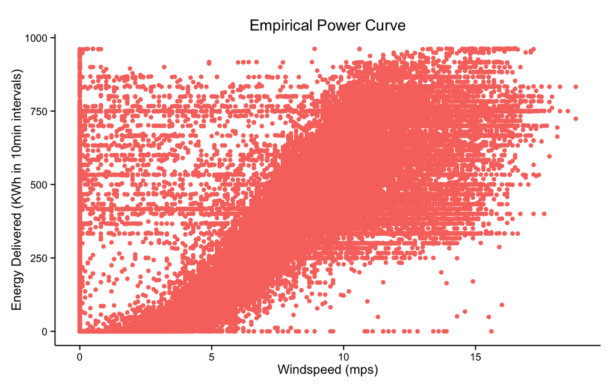

```r
# Plot the wind farm power curve with benchmark comparisons
ggplot(data, aes(x = mean_wind_mps), colour = variable) + geom_point(aes(y = energy_delivered_kwh,
    color = "Energy Delivered")) + scale_y_continuous(name = "Energy Delivered (KWh in 10min intervals)",
    limit = c(0, max(data$energy_delivered_kwh))) + scale_x_continuous(name = "Windspeed (mps)",
    limit = c(0, max(data$mean_wind_mps))) + labs(title = "Empirical Power Curve") +
    theme_classic() + theme(legend.position = "")
```

### Overlay Energy Benchmarks: Kinetic energy in the wind, Betz limit and Turbine Power Curve

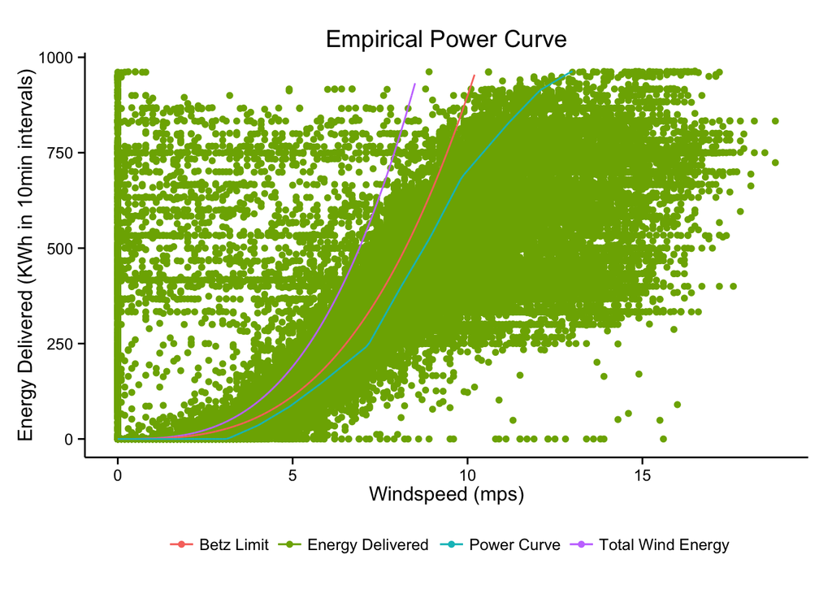

```r
# compute kinetic energy in the wind at each windspeed Wind Power =
# (1/2)*rho*area*(velocity)^3 = [kg/m^3]*[m^2]*[m/s]^3 = [kg*m^2/s^3] =
# [kg*m^2/s^2][1/s] = [Newton-meter]/[second] = [Joules/second] = [Watts]
turbine.rating <- 850
rho <- 1.225  # density of wind (kg/m^3)
area <- 2124  # sweep area of wind turbines (m^2)
n.turbines <- 7  # number of turbines
data$wind_power_kw <- (1/2) * rho * area * (data$mean_wind_mps)^3 * n.turbines/1000  # kW avg power
data$wind_energy_10min_kwh <- data$wind_power_kw * (10/60)  # kWh in 10 min

# compute betz limit
betz.coef <- 16/27
data$betz_limit_10min_kwh <- data$wind_energy_10min_kwh * betz.coef

# Turbine Power Curve
power.curve <- read.csv("v52-850KW-power-curve.csv")
# Keep power curve only for wind speeds below cut out speed (25 m/s)
power.curve <- power.curve[which(power.curve$windspeed_mps <= 25), ]
power.curve$energy_10min_kwh <- power.curve$power_kW * (10/60) * n.turbines
splinefun.power.curve <- splinefun(power.curve$windspeed_mps, power.curve$energy_10min_kwh)
data$power_curve_10min_kwh <- splinefun.power.curve(data$mean_wind_mps)
# Enrsure now power curve values are below zero or above maximum
data$power_curve_10min_kwh[which(data$power_curve_10min_kwh < 0)] <- 0
data$power_curve_10min_kwh[which(data$power_curve_10min_kwh > turbine.rating *
    (10/60) * n.turbines)] <- turbine.rating * (10/60) * n.turbines
```

## 3. Clean the data

Assume the energy delivered measurements are correct, and that all the error is contained in the windspeed measurements.

### Option 1: Remove all records containing suspect/questionable data

```
## [1] "number of records REMOVED: 19670"
## [1] "number of records REMAINING: 31154"
```

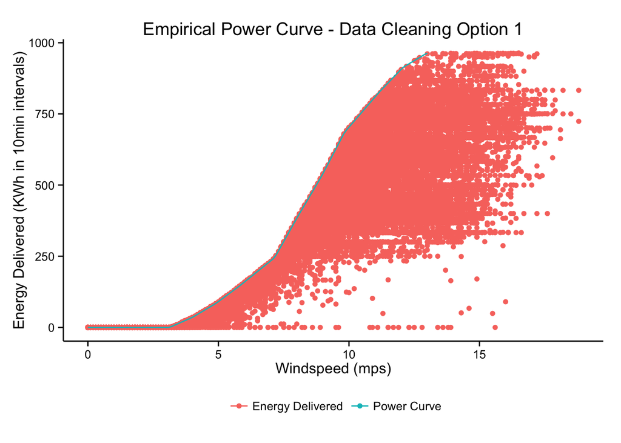

```r
# Remove all data points to the left of the power curve
data.opt1 <- data[which(data$energy_delivered_kwh <= data$power_curve_10min_kwh),
    ]
nrow.orig <- nrow(data)
nrow.new <- nrow(data.opt1)
removed(nrow.orig, nrow.new)  # check how many records have been removed (a lot)
```

### Option 2: Move wind speeds to the left of the power curve to the power curve values

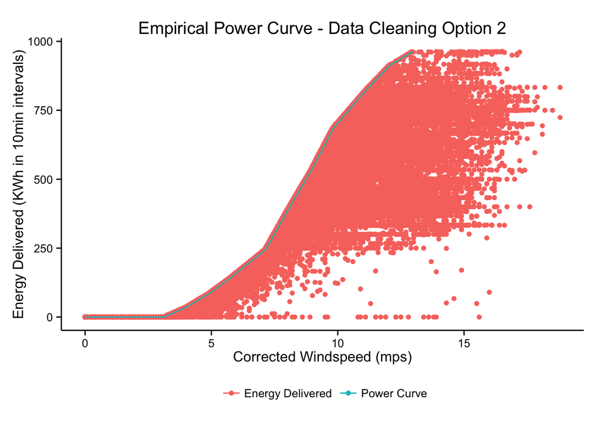

```r
data.opt2 <- data
# Sort power curve in ascending order of electricity generated
power.curve.sorted <- power.curve[order(power.curve$energy_10min_kwh), ]
# Calculate the 'projected' wind speed from the power curve for each entry's
# energy delivered
data.opt2$wind_mps_projected <- power.curve.sorted$windspeed_mps[findInterval(x = data.opt2$energy_delivered_kwh,
    vec = power.curve.sorted$energy_10min_kwh, all.inside = TRUE, rightmost.closed = TRUE)]
# Choose the greater of the wind speed data value and the projected wind
# speed as the corrected wind speed Do not move values off 0 kWh
data.opt2$wind_mps_corrected <- ifelse(data.opt2$energy_delivered_kwh == 0,
    data.opt2$mean_wind_mps, pmax(data.opt2$mean_wind_mps, data.opt2$wind_mps_projected))
# Recalculate power curve values corresponding to corrected wind speeds in
# data frame
data.opt2$corrected_power_curve_10min_kwh <- splinefun.power.curve(data.opt2$wind_mps_corrected)
data.opt2$corrected_power_curve_10min_kwh[which(data.opt2$corrected_power_curve_10min_kwh <
    0)] <- 0
# Recalculate total wind energy
data.opt2$corrected_wind_energy_10min_kwh <- ((1/2) * rho * area * (data.opt2$wind_mps_corrected)^3 *
    n.turbines/1000) * (10/60)
```

4. Total wind energy produced last year

```r
total.energy.kwh.raw <- data.raw$cum_energy_delivered_kwh[nrow(data.raw)] -
    data.raw$cum_energy_delivered_kwh[1] + 2 * 10^7
total.energy.kwh.clean <- sum(data$energy_delivered_kwh)
total.energy.kwh.opt1 <- sum(data.opt1$energy_delivered_kwh)
total.energy.kwh.opt2 <- sum(data.opt2$energy_delivered_kwh)
data.frame(total.energy.kwh.raw, total.energy.kwh.clean, total.energy.kwh.opt1,
    total.energy.kwh.opt2)
```

```
##   total.energy.kwh.raw total.energy.kwh.clean total.energy.kwh.opt1
## 1             21233334               20915510              13938895
##   total.energy.kwh.opt2
## 1              20915510
```

5. Capacity Factor

```r
cf.raw <- total.energy.kwh.raw/(nrow(data.raw) * (10/60) * turbine.rating *
    n.turbines)
cf.clean <- total.energy.kwh.clean/(nrow(data) * (10/60) * turbine.rating *
    n.turbines)
cf.opt1 <- total.energy.kwh.opt1/(nrow(data.opt1) * (10/60) * turbine.rating *
    n.turbines)
cf.opt2 <- total.energy.kwh.opt2/(nrow(data.opt2) * (10/60) * turbine.rating *
    n.turbines)
data.frame(cf.raw, cf.clean, cf.opt1, cf.opt2)
```

```
##      cf.raw  cf.clean   cf.opt1   cf.opt2
## 1 0.4073776 0.4149864 0.4511789 0.4149864
```

6. Total Possible Energy

```r
total.possible.kwh.clean <- sum(data$power_curve_10min_kwh)
total.possible.kwh.opt1 <- sum(data.opt1$power_curve_10min_kwh)
total.possible.kwh.opt2 <- sum(data.opt2$corrected_power_curve_10min_kwh)
data.frame(total.possible.kwh.clean, total.possible.kwh.opt1, total.possible.kwh.opt2)
```

```
##   total.possible.kwh.clean total.possible.kwh.opt1 total.possible.kwh.opt2
## 1                 23909431                19756331                26679906
```

7. Uncurtailed Capacity Factor

```r
cf.uncurtailed.clean <- total.possible.kwh.clean/(nrow(data) * (10/60) * turbine.rating *
    n.turbines)
cf.uncurtailed.opt1 <- total.possible.kwh.opt1/(nrow(data.opt1) * (10/60) *
    turbine.rating * n.turbines)
cf.uncurtailed.opt2 <- total.possible.kwh.opt2/(nrow(data.opt2) * (10/60) *
    turbine.rating * n.turbines)
data.frame(cf.uncurtailed.clean, cf.uncurtailed.opt1, cf.uncurtailed.opt2)
```

```
##   cf.uncurtailed.clean cf.uncurtailed.opt1 cf.uncurtailed.opt2
## 1            0.4743891           0.6394797           0.5293583
```

8. Turbine Efficiency

```r
data$turbine.eff <- data$energy_delivered_kwh/data$wind_energy_10min_kwh
data$turbine.eff[which(data$turbine_eff == "NaN")] <- 0
turbine.eff.clean <- total.energy.kwh.clean/sum(data$wind_energy_10min_kwh)
data.opt1$turbine.eff <- data.opt1$energy_delivered_kwh/data.opt1$wind_energy_10min_kwh
data.opt1$turbine.eff[which(data.opt1$turbine_eff == "NaN")] <- 0
turbine.eff.opt1 <- total.energy.kwh.opt1/sum(data.opt1$wind_energy_10min_kwh)
data.opt2$turbine.eff <- data.opt2$energy_delivered_kwh/data.opt2$corrected_wind_energy_10min_kwh
data.opt2$turbine.eff[which(data.opt2$turbine_eff == "NaN")] <- 0
turbine.eff.opt2 <- total.energy.kwh.opt2/sum(data.opt2$corrected_wind_energy_10min_kwh)
data.frame(turbine.eff.clean, turbine.eff.opt1, turbine.eff.opt2)
```

```
##   turbine.eff.clean turbine.eff.opt1 turbine.eff.opt2
## 1         0.3123039        0.2400258        0.2862848
```

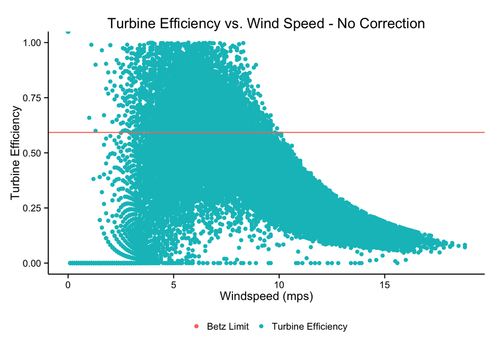

```r
# Plot turbine efficiency vs. wind speed for uncorrected data
ggplot(data, aes(x = mean_wind_mps)) + geom_point(aes(y = turbine.eff, color = "Turbine Efficiency")) +
    geom_hline(aes(yintercept = betz.coef, color = "Betz Limit")) + scale_y_continuous(name = "Turbine Efficiency",
    limit = c(0, 1)) + scale_x_continuous(name = "Windspeed (mps)", limit = c(0,
    max(data$mean_wind_mps))) + labs(title = "Turbine Efficiency vs. Wind Speed - No Correction") +
    theme_classic() + theme(legend.position = "bottom", legend.title = element_blank())
```

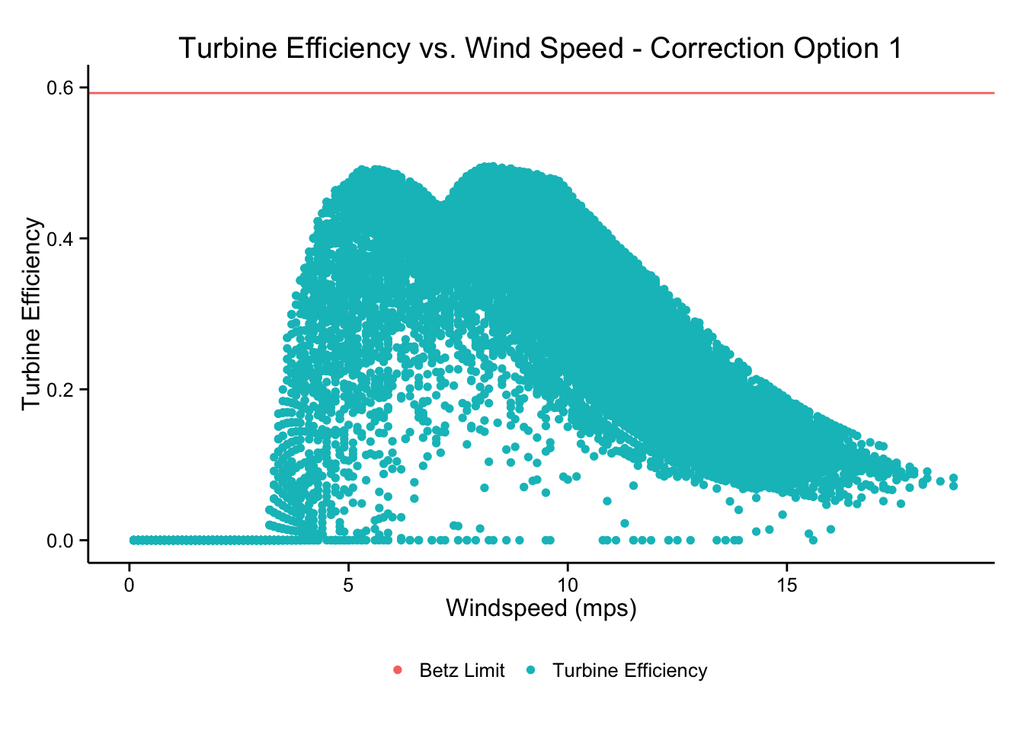

```r
# plot turbine efficiency vs wind speed for correction option 1
ggplot(data.opt1, aes(x = mean_wind_mps)) + geom_point(aes(y = turbine.eff,
    color = "Turbine Efficiency")) + geom_hline(aes(yintercept = betz.coef,
    color = "Betz Limit")) + scale_y_continuous(name = "Turbine Efficiency",
    limit = c(0, 0.6)) + scale_x_continuous(name = "Windspeed (mps)", limit = c(0,
    max(data.opt1$mean_wind_mps))) + labs(title = "Turbine Efficiency vs. Wind Speed - Correction Option 1") +
    theme_classic() + theme(legend.position = "bottom", legend.title = element_blank())
```

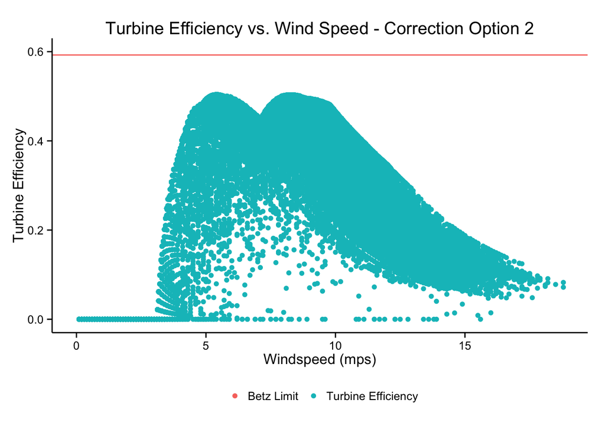

```r
# plot turbine efficiency vs wind speed for correction option 2
ggplot(data.opt2, aes(x = wind_mps_corrected)) + geom_point(aes(y = turbine.eff,
    color = "Turbine Efficiency")) + geom_hline(aes(yintercept = betz.coef,
    color = "Betz Limit")) + scale_y_continuous(name = "Turbine Efficiency",
    limit = c(0, 0.6)) + scale_x_continuous(name = "Windspeed (mps)", limit = c(0,
    max(data.opt2$wind_mps_corrected))) + labs(title = "Turbine Efficiency vs. Wind Speed - Correction Option 2") +
    theme_classic() + theme(legend.position = "bottom", legend.title = element_blank())
```

9. Characterization of Weibull distribution

```r
# Uncorrected data Remove rows with zero wind speed
data.weibull <- subset(data, mean_wind_mps >= 0.1)

# Weibull fit for uncorrected data Uses package 'fitdistrplus'
weibull.fit <- fitdist(data.weibull$mean_wind_mps, distr = "weibull")
summary(weibull.fit)
```

```
## Fitting of the distribution ' weibull ' by maximum likelihood
## Parameters :
##       estimate  Std. Error
## shape 2.635216 0.009849236
## scale 9.511603 0.017099360
## Loglikelihood:  -130030.6   AIC:  260065.1   BIC:  260082.7
## Correlation matrix:
##           shape     scale
## shape 1.0000000 0.2867651
## scale 0.2867651 1.0000000
```

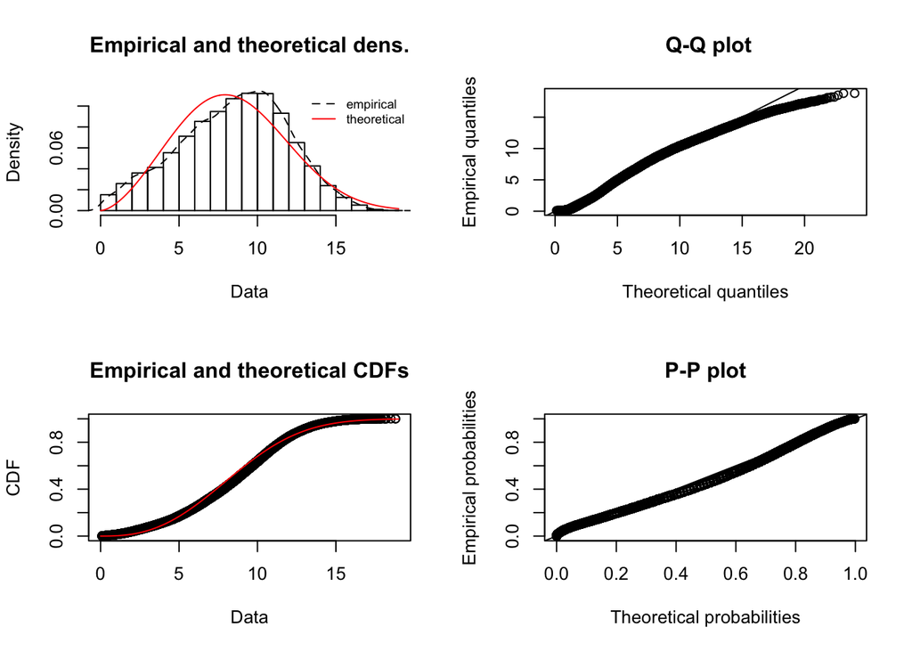

```r
plot(weibull.fit, demp = TRUE)
```

```r
# Correction Option 1 Remove rows with zero wind speed
data.opt1.weibull <- subset(data.opt1, mean_wind_mps >= 0.1)

# Weibull fit for corrected data - Option 1
weibull.fit.opt1 <- fitdist(data.opt1.weibull$mean_wind_mps, distr = "weibull")
summary(weibull.fit.opt1)
```

```
## Fitting of the distribution ' weibull ' by maximum likelihood
## Parameters :
##        estimate Std. Error
## shape  3.242374 0.01557217
## scale 10.810488 0.01961433
## Loglikelihood:  -82896.26   AIC:  165796.5   BIC:  165813.2
## Correlation matrix:
##           shape     scale
## shape 1.0000000 0.2592921
## scale 0.2592921 1.0000000
```

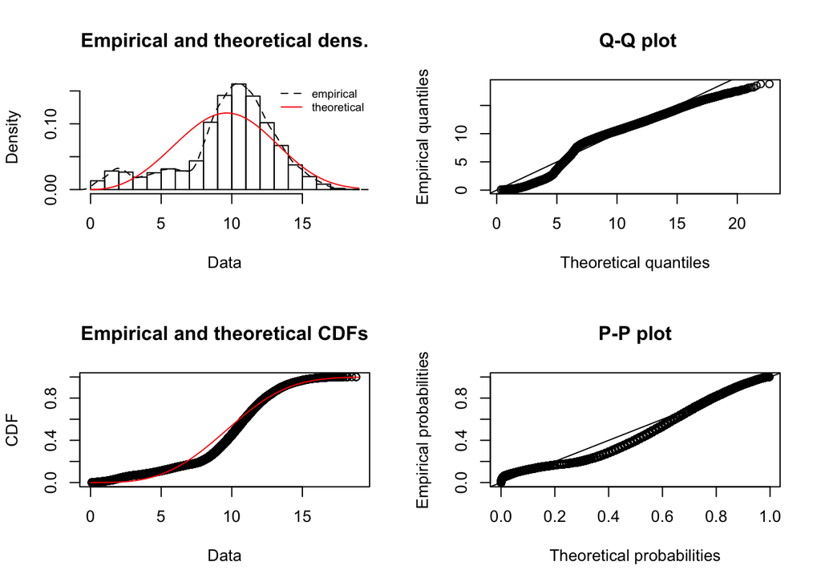

```r
plot(weibull.fit.opt1, demp = TRUE)
```

```r
# Correction Option 2 Remove rows with zero wind speed
data.opt2.weibull <- subset(data.opt2, wind_mps_corrected >= 0.1)

# Weibull fit for corrected data - Option 2
weibull.fit.opt2 <- fitdist(data.opt2.weibull$wind_mps_corrected, distr = "weibull")
summary(weibull.fit.opt2)
```

```
## Fitting of the distribution ' weibull ' by maximum likelihood
## Parameters :
##       estimate Std. Error
## shape 3.136102 0.01122476
## scale 9.884429 0.01464118
## Loglikelihood:  -130228.6   AIC:  260461.3   BIC:  260479
## Correlation matrix:
##           shape     scale
## shape 1.0000000 0.2913625
## scale 0.2913625 1.0000000
```

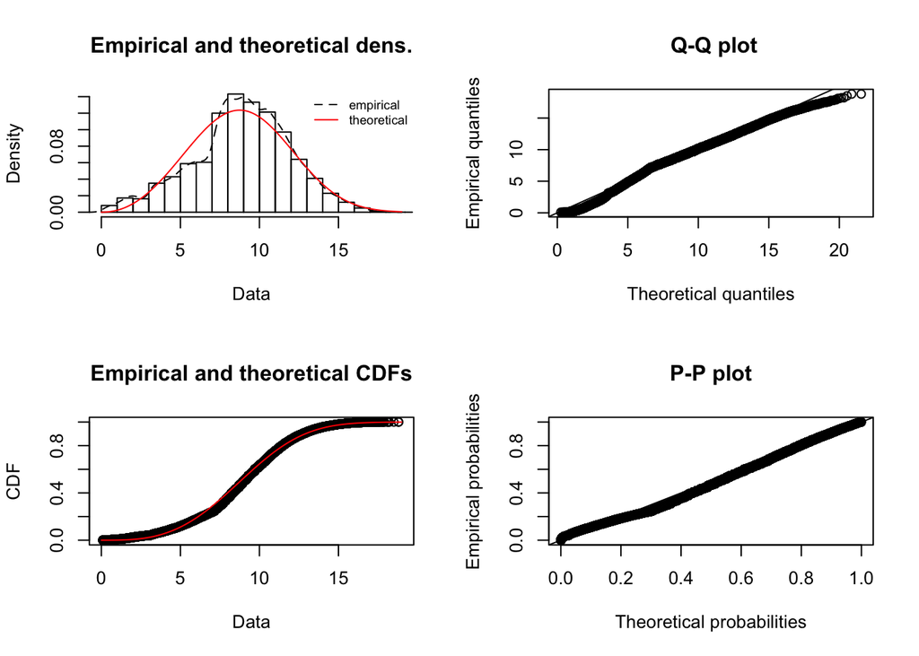

```r
plot(weibull.fit.opt2, demp = TRUE)
```

# Part 2: Grid Integration of Wind Energy

We need to get the hourly wind-generated electricity supply from our Option 2 corrected data:

```r
# Load in the date_time and corrected_wind_energy_10min_kwh from Option 2
# for the wind-generated electricity supply
supply.orig <- data.opt2[, c("date_time", "corrected_power_curve_10min_kwh")]
# Create columns for dates and hours
supply.orig$date <- as.Date(supply.orig$date_time)
supply.orig$hour <- hour(supply.orig$date_time)
# Get hourly wind-generated electricity
supply.hrly <- ddply(supply.orig, .(date, hour), .fun = summarise, wind.supply.kwh = sum(corrected_power_curve_10min_kwh))
# Create date.time column from 'date' and 'hour'
supply.hrly$date.time <- as.POSIXct(paste(as.character(supply.hrly$date), as.character(supply.hrly$hour),
    sep = " "), format = "%Y-%m-%d %H", tz = "UTC")
```

Create a data frame that will include the wind-generated electricity supply and the island demand:

```r
# Initiate data frame as a sequence of date-times for each hour of the year
start.datetime <- as.POSIXct("2013-01-01 0:00", format = "%Y-%m-%d %H:%M", tz = "UTC")
end.datetime <- as.POSIXct("2013-12-31 23:00", format = "%Y-%m-%d %H:%M", tz = "UTC")
data.pt2 <- as.data.frame(seq(from = start.datetime, to = end.datetime, by = 3600))
names(data.pt2) <- "date.time"
# Add month and hour columns, as this will be required later
data.pt2$month <- month(data.pt2$date.time)
data.pt2$hour <- hour(data.pt2$date.time)
# Use 'match' function to add wind-generated electricity supply to the data
# frame. If no match, set value to zero (i.e. if we don't have a supply
# point, assume the supply is zero).
data.pt2$wind.supply.kwh <- supply.hrly$wind.supply.kwh[match(data.pt2$date.time,
    supply.hrly$date.time, nomatch = NA)]
data.pt2$wind.supply.kwh[is.na(data.pt2$wind.supply.kwh)] <- 0
# Read in demand data and add to data.pt2
demand.data <- read.csv("island_demand_data.csv")
data.pt2$demand.kwh <- demand.data$demand.kWh
```

Calculate the hourly curtailment and capacity factor:

```r
data.pt2$wind.curtail.kwh <- ifelse(data.pt2$wind.supply.kwh <= data.pt2$demand.kwh,
    0, data.pt2$wind.supply.kwh - data.pt2$demand.kwh)
cf.nostorage <- (sum(data.pt2$wind.supply.kwh) - sum(data.pt2$wind.curtail.kwh))/(nrow(data.pt2) *
    turbine.rating * n.turbines)
```

Compute hourly curtailment by month and create table:

```r
# Create empty 12 column by 24 row data frame
hrly.curtail.kwh <- as.data.frame(matrix(0, nrow = 24, ncol = 12))
colnames(hrly.curtail.kwh) <- c(1:12)
rownames(hrly.curtail.kwh) <- c(1:24)
# Fill in data frame with average hourly curtailment values
for (i in 1:12) {
    data.month <- data.pt2[which(data.pt2$month == i), ]
    hrly.curtail.kwh[, i] <- ddply(data.month, .(hour), .fun = summarise, curtail.means = mean(wind.curtail.kwh))[,
        2]
}
hrly.curtail.kwh
```

```
##             1         2           3          4          5         6
## 1    0.000000  0.000000   0.0000000   0.000000   0.000000   0.00000
## 2   43.510489 28.443411   0.0000000   4.208351  94.051977   0.00000
## 3   49.129746 19.839711   0.5281138  18.060943 164.312079   0.00000
## 4   51.029157 55.223013  24.3794929  32.733596 183.055583   0.00000
## 5   51.860875 37.377760  23.3394314  33.151039  86.432232   0.00000
## 6   41.679940  0.533948   0.0000000  25.185300  31.571201   0.00000
## 7    4.451425  0.000000   0.0000000   0.000000 194.163960   0.00000
## 8    0.000000  0.000000 189.3035244 181.353919  11.548990   0.00000
## 9  137.833226  0.000000 139.7969348 108.148010   0.000000   0.00000
## 10  99.791131  0.000000   0.0000000   0.000000  19.605827   0.00000
## 11  15.308804  0.000000   0.0000000   0.000000 187.390001 149.53556
## 12   0.000000  0.000000   0.0000000   0.000000   0.000000 134.10222
## 13   0.000000  0.000000   0.0000000   0.000000   0.000000 149.53556
## 14   0.000000  0.000000   0.0000000   0.000000   0.000000  64.60222
```

[output cut: 35 more lines]

Compute hourly wind-generated electricity production by month and create table:

```r
# Create empty 12 column by 24 row data frame
hrly.production.kwh <- as.data.frame(matrix(0, nrow = 24, ncol = 12))
colnames(hrly.production.kwh) <- c(1:12)
rownames(hrly.production.kwh) <- c(1:24)
# Fill in data frame with average hourly curtailment values
for (i in 1:12) {
    data.month <- data.pt2[which(data.pt2$month == i), ]
    hrly.production.kwh[, i] <- ddply(data.month, .(hour), .fun = summarise,
        production.means = mean(wind.supply.kwh))[, 2]
}
hrly.production.kwh
```

```
##           1        2        3        4        5        6        7
## 1  2756.819 2616.204 2240.976 2698.406 2980.950 2626.800 1657.471
## 2  3205.525 2918.665 2541.755 3104.199 3487.664 3077.211 1798.608
## 3  3092.998 2884.474 2467.461 3076.771 3633.623 3013.896 1640.564
## 4  3006.608 2844.739 2349.204 3055.037 3637.262 2828.366 1652.117
## 5  3037.774 2823.216 2311.914 3066.906 3610.218 2824.911 1725.639
## 6  3205.965 2749.269 2393.104 3132.974 3573.363 2819.270 1859.918
## 7  3359.091 2942.483 2431.827 3173.495 3621.009 2837.815 1945.665
## 8  3591.501 3072.193 2542.881 3411.849 3771.511 3080.935 2020.417
## 9  3863.981 3422.721 2913.861 3819.542 4131.968 3618.942 2429.849
## 10 4194.826 3773.457 3277.945 4011.132 4391.850 3931.249 2345.090
## 11 4463.704 3895.527 3353.767 3936.219 4494.691 4040.640 2439.913
## 12 4399.505 3697.158 3547.267 4039.384 4479.701 4030.764 2485.840
## 13 4346.447 4014.747 3543.924 3997.083 4466.337 4173.970 2485.584
## 14 4319.966 4102.082 3588.511 3878.465 4609.721 4178.647 2631.758
```

[output cut: 35 more lines]

# Pumped hydro model

```r
# Pumped hydro storage capacity
ph.cap.kwh <- 5000
# Assume initial amount stored is zero
ph.stor.init.kwh <- 0
# Pump efficiency
eff.pump <- 0.85
# Turbine efficiency
eff.turb <- 0.9
# We'll need to develop a 'for' loop, so we'll add columns to our data frame
# for the amount of energy stored in the pumped hydro system at the start
# and end of each time step
data.pt2$ph.stor.start.kwh <- 0
data.pt2$ph.stor.end.kwh <- 0
# For loop to determine, at each hour, how much electricity is stored in the
# pumped hydro system and how much is drawn from the system.
for (h in 1:nrow(data.pt2)) {
    ifelse(h == 1, data.pt2$ph.stor.start.kwh[h] <- ph.stor.init.kwh, data.pt2$ph.stor.start.kwh[h] <- data.pt2$ph.stor.end.kwh[h -
        1])
    data.pt2$ph.stor.end.kwh[h] <- ifelse(data.pt2$wind.supply.kwh[h] > data.pt2$demand.kwh[h],
        min(data.pt2$ph.stor.start.kwh[h] + (data.pt2$wind.supply.kwh[h] - data.pt2$demand.kwh[h]) *
            eff.pump, ph.cap.kwh), max(data.pt2$ph.stor.start.kwh[h] + (data.pt2$wind.supply.kwh[h] -
            data.pt2$demand.kwh[h]) * eff.turb, 0))
    max(min(data.pt2$ph.stor.start.kwh[h] + (data.pt2$wind.supply.kwh[h] - data.pt2$demand.kwh[h]),
        ph.cap.kwh), 0)
    data.pt2$wind.curtail.afterph.kwh[h] <- ifelse((data.pt2$ph.stor.end.kwh[h] -
        data.pt2$ph.stor.start.kwh[h]) > 0, data.pt2$wind.curtail.kwh[h] - (data.pt2$ph.stor.end.kwh[h] -
        data.pt2$ph.stor.start.kwh[h]), data.pt2$wind.curtail.kwh[h])
}
# Calculate capacity factor with pumped hydro
cf.withph <- (sum(data.pt2$wind.supply.kwh) - sum(data.pt2$wind.curtail.afterph.kwh))/(nrow(data.pt2) *
    turbine.rating * n.turbines)
```

Compare capacity factors to see affects of the pumped hydro storage system:

```r
# Capaity factor without storage
cf.nostorage
```

```
## [1] 0.508653
```

```r
# Capacity factor with storage
cf.withph
```

```
## [1] 0.5108216
```

```r
# Absoluate increase in capacity factor
cf.withph - cf.nostorage
```

```
## [1] 0.00216858
```

```r
# Relative increase in capacity factor
(cf.withph - cf.nostorage)/cf.nostorage
```

```
## [1] 0.004263377
```

Only a small difference is seen due to the low curtailment levels, due to demand generally being higher than wind-generated electricity supply.